# Cechy ilościowe

# Graficzne statystyki opisowe

Powyżej opisane statystyki liczbowe można przedstawić graficznie. Prezentacja graficzna ma tę zaletę, że wyćwiczone oko potrafi szybko wiele dowiedzieć się z danych.

Opisując zmienną ilościową mamy do wyboru różne sposoby prezentacji, w zależności od tego ile informacji chcemy przedstawić.

Przypuśćmy, że chcemy pokazać wyłącznie średnią. Jedną liczbę. Zrobimy to za pomocą wykresu słupkowego. Wykres słupkowy można w programie R wyznaczyć funkcją `barplot()`.

```r
(srednia = mean(auta2012$Przebieg.w.km, na.rm=TRUE))
```

```
## [1] 147167.4
```

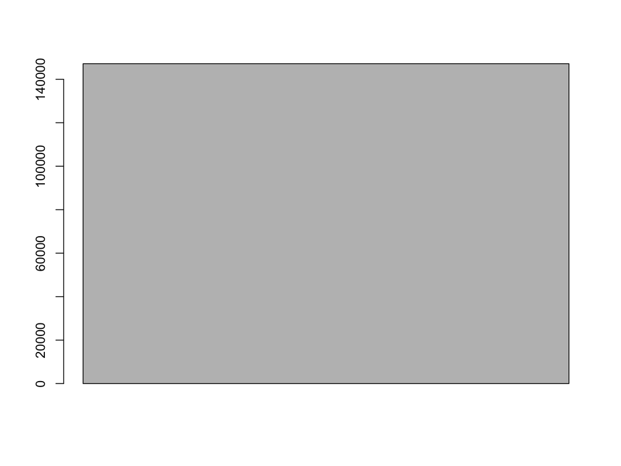

```r
barplot(srednia)
```

Jeden słupek wygląda dziwnie, mało czytelnie. To dlatego, że wykres przedstawia jedną liczbę, trudno więc do czegoś się na nim odnieść.

Ciekawszy będzie wykres, przedstawiający więcej informacji. Powyżej pokazaliśmy wynik funkcji `summary()`, prezentujących sześć charakterystycznych informacji o rozkładzie (min, max, kwartyle i średnią). Pięć z nich, za wyjątkiem średniej, przedstawia wykres pudełko-wąsy, który w R można wykonać używając funkcji `boxplot()`.

W poniższym przykładzie przedstawiamy te pięć liczb dla zmiennej `Przebieg.w.km`. Argument `horizontal=TRUE` powoduje, że wykres rysowany jest poziomo, argument `range = 0` powoduje, że nie są wyznaczane wartości odstające (a nie mówiliśmy co to za wartości, więc ich nie wyznaczajmy, wrócimy do tego tematu później).

```r
summary(auta2012$Przebieg.w.km)
```

```
##      Min.   1st Qu.    Median      Mean   3rd Qu.      Max.      NA's
## 1.000e+00 8.500e+04 1.400e+05 1.472e+05 1.800e+05 1.000e+09     39559
```

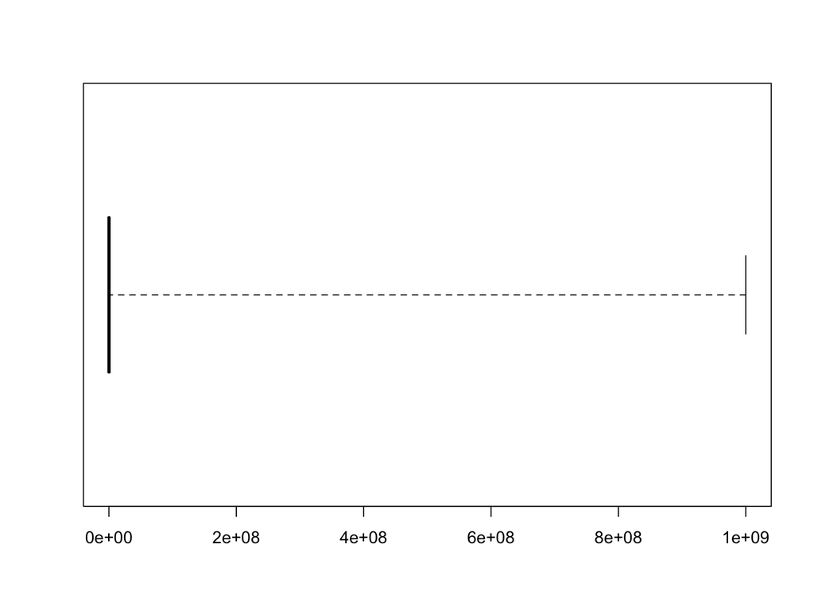

```r
boxplot(auta2012$Przebieg.w.km,
        horizontal=TRUE, range = 0)
```

Dane bardzo często są zanieczyszczone a graficzne prezentacje pozwalają nam to łatwo zauważyć. Tak jest i w tym przypadku. Oczyśćmy te dane, usuwając wszystkie wiersze, dla których cecha `Przebieg.w.km` przyjmuje wartości powyżej 1 000 000 km. Takie czyszczenie możemy przeprowadzić używając funkcji `filter()` z pakietu `dplyr`.

```r
library(dplyr)
auta2012wybrane <- auta2012 %>%
  filter(Przebieg.w.km < 1000000)

summary(auta2012wybrane$Przebieg.w.km)
```

```
##    Min. 1st Qu.  Median    Mean 3rd Qu.    Max.
##       1   85000  140000  132900  180000  972000
```

Teraz możemy narysować wykres pudełko-wąsy dla oczyszczonych danych.

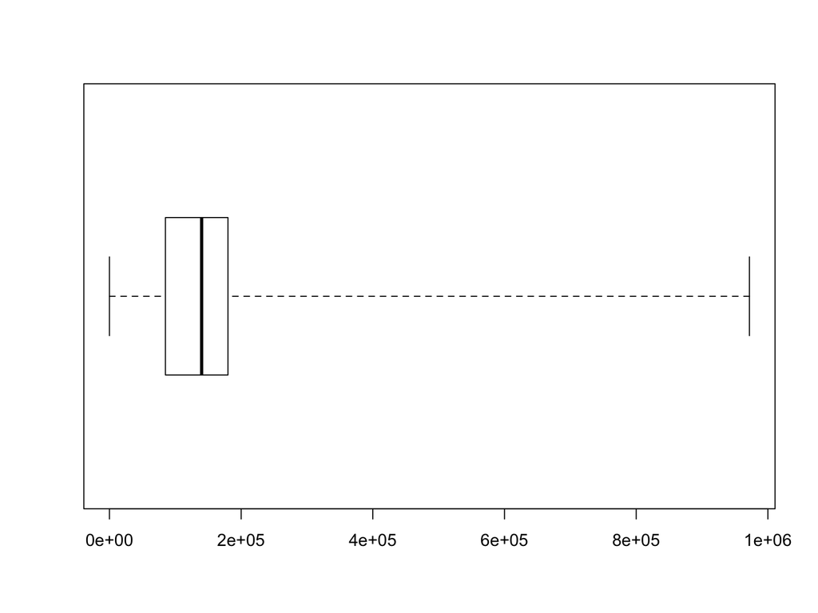

```r
boxplot(auta2012wybrane$Przebieg.w.km, horizontal=TRUE, range=0)
```

Każdy z elementów tego wykresu (lewy wąs, lewa część pudełka, prawa część pudełka, prawy wąs) przedstawia 1/4 danych. Z wykresu tego możemy łatwo odczytać, że 3/4 danych dotyczy aut o przebiegu poniżej 200 tys km. Jedynie 1/4 danych ma wyższe wartości i dla tych aut rozpiętość jest bardzo duża.

Jeżeli chcemy zaprezentować bardziej szczegółowe dane o przebiegu, możemy wykorzystać histogram. Słowo histogram pochodzi z języka greckiego, pochodzi ze złożenia słów histos i gramma. **Pierwsze oznacza rzeczy stojące pionowo, drugie oznacza zapis. W sumie chodzi o przedstawienie danych z użyciem pionowych słupków.** PCH: Ekstremalnie ważna informacja. Zabrakło wcześniej informacji co znaczy barplot i kilka innych nazw ;)

Aby wykonać w programie R histogram, można wykorzystać funkcję `hist()`. Pierwszy argument określa dane, które mają być pokazane, drugi argument określa na ile przedziałów ma być podzielony zakres zmienności. Histogram przedstawia liczbę samochodów, których przebieg jest w zakresie opisanym przez określone pudełko.

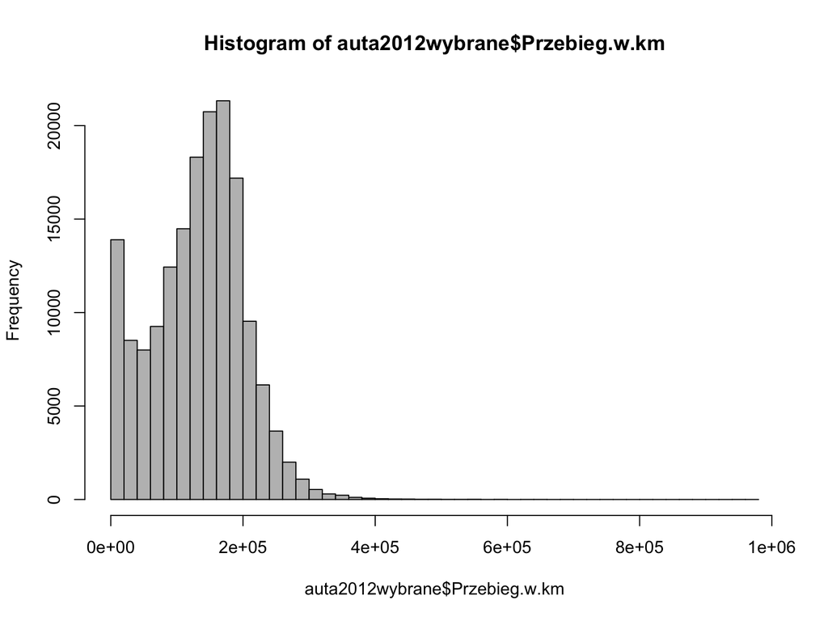

```r
hist(auta2012wybrane$Przebieg.w.km, 60, col="grey")
```

Histogram przedstawia znacznie więcej informacji niż wykres pudełko-wąsy. Im wyższy słupek, tym więcej było aut, o przebiegu w określonym przedziale. Dwie najwyższe wyspy to ta w pobliżu 0 oraz ta w pobliży 180 tys km. Oznacza to, że w zbiorze danych jest jedna duża grupa aut o bardzo małym przebiegu, aut o przebiegu w okolicy 50 tys km jest mniej, aut o przebiegu w okolicy 150 tys km jest bardzo dużo a aut o przebiegu ponad 300 tys km jest już bardzo mało, pojedyncze sztuki.

Jak widzimy zmienną ilościowa możemy opisać z różnym poziomem szczegółowości. Im większa szczegółowość tym więcej elementów na wykresie. Im więcej elementów tym więcej możemy odczytać ale jest to też trudniejsze.

# Zadania:

- Przedstaw graficznie za pomocą wykresu pudełko-wąsy oraz histogramu rozkład cechy `Cena.w.PLN`.
- Zwróć uwagę, że pojedyncze auta o bardzo wysokich cenach, powodują że wykres jest mało czytelny. Oczyść te dane, pozostawiają tylko auta o cenie poniżej 100 tys pln. Następnie przedstaw rozkład cen aut w segmencie aut do 100 tys pln.
- Aut w jakiej cenie jest najwięcej wśród zebranych ogłoszeń?

# Odpowiedzi:

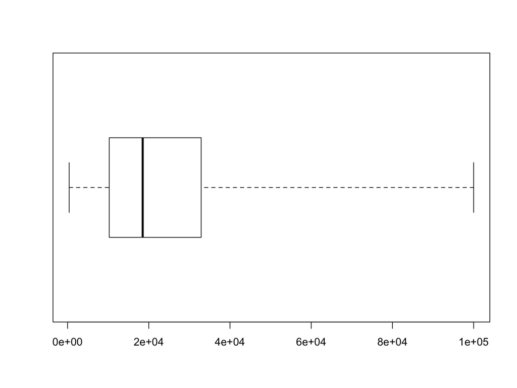

```r
library(dplyr)
auta2012wybrane <- auta2012 %>%
  filter(Cena.w.PLN < 100000)

boxplot(auta2012wybrane$Cena.w.PLN, horizontal = TRUE, range = 0)
```

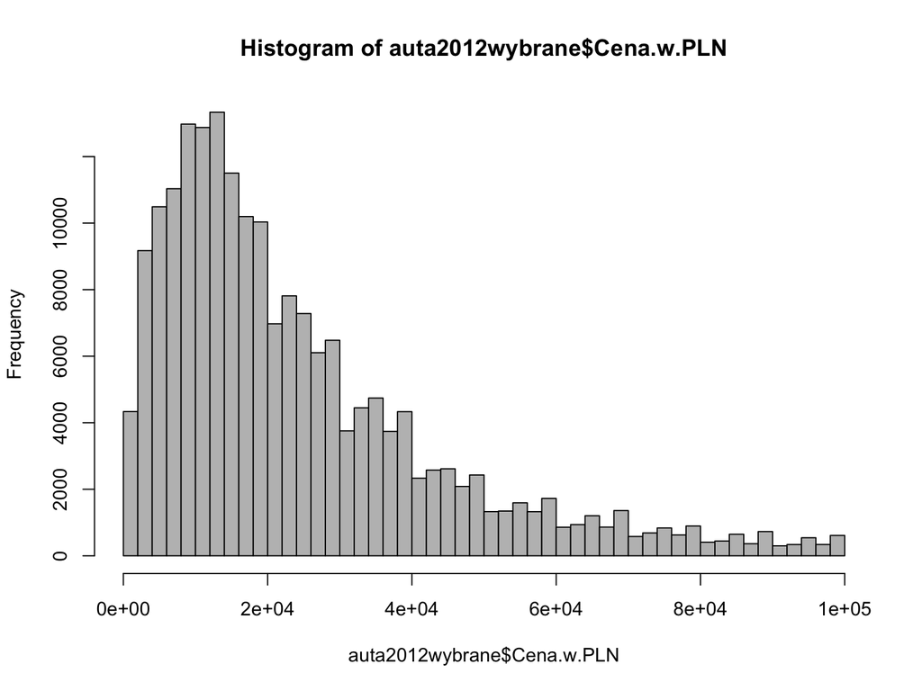

```r
hist(auta2012wybrane$Cena.w.PLN, 50, col="grey")
```